# ESM 206 Lab 8

Jaleise Hall

11/18/2019

### 1. One-way ANOVA to compare penguin flipper lengths

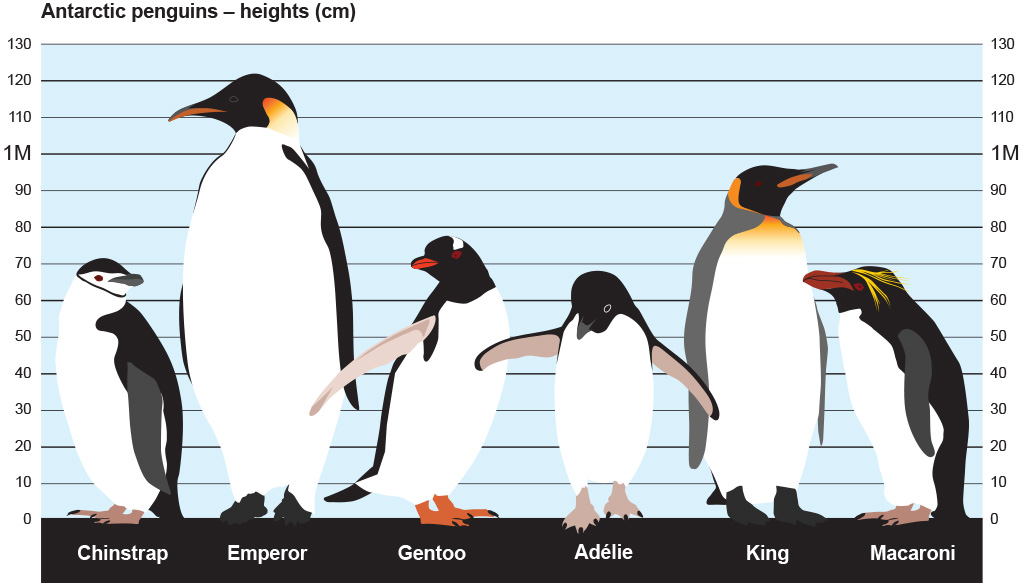

Read in data, get some counts, etc:

Find some counts based on species and sex:

```
## # A tibble: 9 x 3
##   species                                   sex        n
##   <chr>                                     <chr>  <int>
## 1 Adelie Penguin (Pygoscelis adeliae)       FEMALE    73
## 2 Adelie Penguin (Pygoscelis adeliae)       MALE      73
## 3 Adelie Penguin (Pygoscelis adeliae)       <NA>       6
## 4 Chinstrap penguin (Pygoscelis antarctica) FEMALE    34
## 5 Chinstrap penguin (Pygoscelis antarctica) MALE      34
## 6 Gentoo penguin (Pygoscelis papua)         .          1
## 7 Gentoo penguin (Pygoscelis papua)         FEMALE    58
## 8 Gentoo penguin (Pygoscelis papua)         MALE      61
## 9 Gentoo penguin (Pygoscelis papua)         <NA>       4
```

We’re going to ask: Is there a significant difference in mean flipper length for female penguins across the 3 species?

Create a subset that only contains observations for femal penguins, then visually explore the distributions for each species:

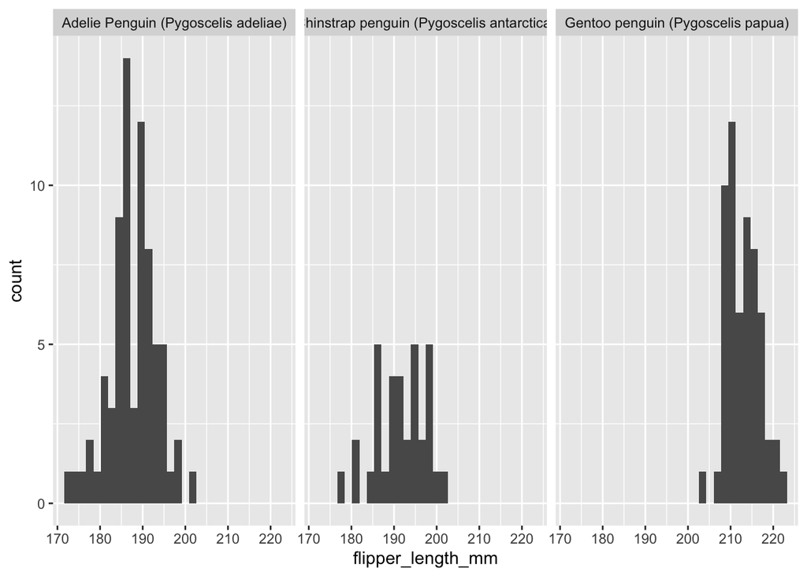

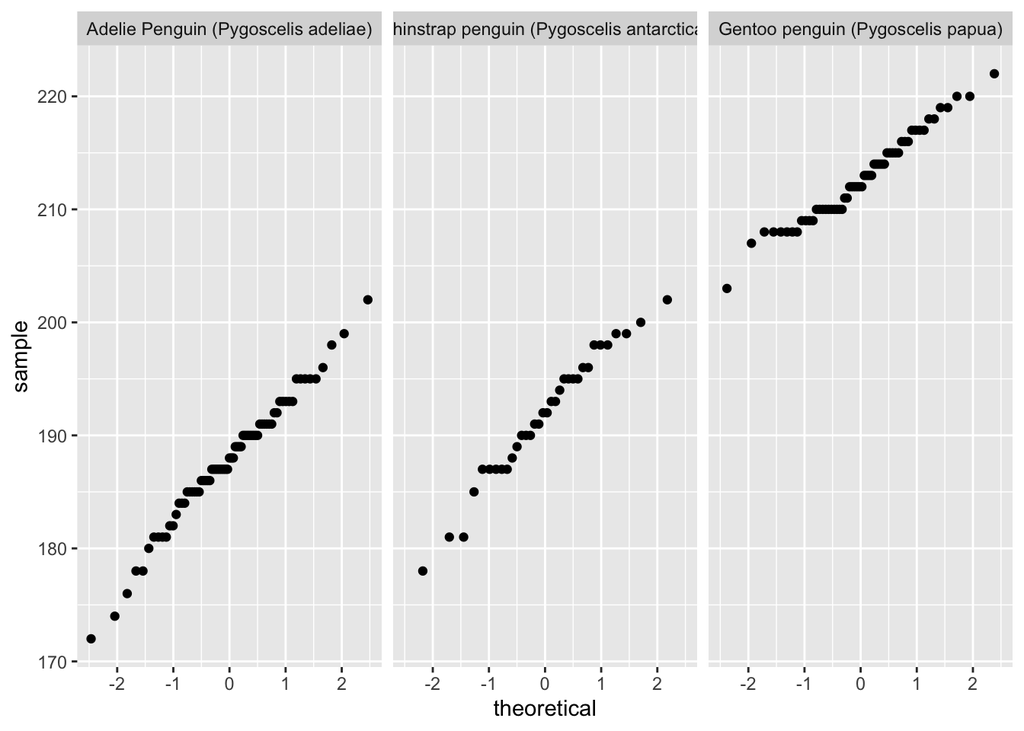

Find some summary statistics using group_by + summarize

Levene’s test:

```
## Levene's Test for Homogeneity of Variance (center = median)
##        Df F value  Pr(>F)
## group   2  2.9012 0.05782 .
##       162
## ---
## Signif. codes:  0 '***' 0.001 '**' 0.01 '*' 0.05 '.' 0.1 ' ' 1
```

Beeswarm plot with mean and standard deviation overlayed:

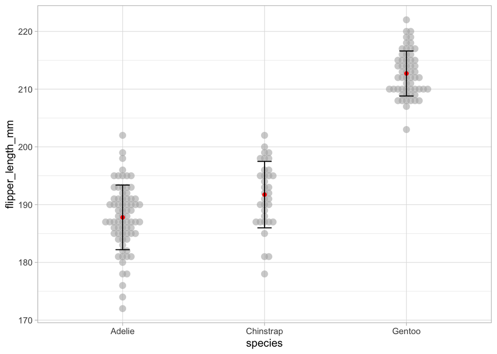

```
##              Df Sum Sq Mean Sq F value Pr(>F)
## species       2  21416   10708   411.8 <2e-16 ***
## Residuals   162   4213      26
## ---
## Signif. codes:  0 '***' 0.001 '**' 0.01 '*' 0.05 '.' 0.1 ' ' 1
```

…well, if the mean aren’t equal, then which ones differ? - do a post-hoc test

```
##   Tukey multiple comparisons of means
##     95% family-wise confidence level
##
## Fit: aov(formula = flipper_length_mm ~ species, data = penguin_f)
##
## $species
##                                                                                    diff
## Chinstrap penguin (Pygoscelis antarctica)-Adelie Penguin (Pygoscelis adeliae)  3.940774
## Gentoo penguin (Pygoscelis papua)-Adelie Penguin (Pygoscelis adeliae)         24.912376
## Gentoo penguin (Pygoscelis papua)-Chinstrap penguin (Pygoscelis antarctica)   20.971602
##                                                                                     lwr
## Chinstrap penguin (Pygoscelis antarctica)-Adelie Penguin (Pygoscelis adeliae)  1.436275
## Gentoo penguin (Pygoscelis papua)-Adelie Penguin (Pygoscelis adeliae)         22.790647
## Gentoo penguin (Pygoscelis papua)-Chinstrap penguin (Pygoscelis antarctica)   18.366227
##                                                                                     upr
## Chinstrap penguin (Pygoscelis antarctica)-Adelie Penguin (Pygoscelis adeliae)  6.445272
## Gentoo penguin (Pygoscelis papua)-Adelie Penguin (Pygoscelis adeliae)         27.034105
## Gentoo penguin (Pygoscelis papua)-Chinstrap penguin (Pygoscelis antarctica)   23.576977
##                                                                                   p adj
## Chinstrap penguin (Pygoscelis antarctica)-Adelie Penguin (Pygoscelis adeliae) 0.0007922
## Gentoo penguin (Pygoscelis papua)-Adelie Penguin (Pygoscelis adeliae)         0.0000000
## Gentoo penguin (Pygoscelis papua)-Chinstrap penguin (Pygoscelis antarctica)   0.0000000
```

### Part 2: Tables and proportions and chi-square

```
## # A tibble: 2 x 3
##   partyid            None Catholic
##   <fct>             <int>    <int>
## 1 Strong republican   117      481
## 2 Strong democrat     554      720
```

Make a nice table of counts and proportions within each group:

```
##            partyid        None    Catholic
##  Strong republican 117 (19.6%) 481 (80.4%)
##    Strong democrat 554 (43.5%) 720 (56.5%)
```

| partyid | None | Catholic |
| --- | --- | --- |
| Strong republican | 117 (19.6%) | 481 (80.4%) |
| Strong democrat | 554 (43.5%) | 720 (56.5%) |

Run chi-square test for independence.

First, get only a contingency table (values only; no additional colums)

```
## # A tibble: 2 x 2
##    None Catholic
##   <int>    <int>
## 1   117      481
## 2   554      720
```

A couple ways to ask a question that would prompt chi-square:

- Is there a significant difference in religious affiliation (none/catholic) between strong democrats and strong republicans?
- Is there a significant association between party affiliation (stron dem/strong repub) on religious affiliation (none/catholic)

```
##
##  Pearson's Chi-squared test with Yates' continuity correction
##
## data:  chi_counts
## X-squared = 100.22, df = 1, p-value < 2.2e-16
```

H0: No significant association between categories (political affiliation and religious affiliation are independent)